# Degrowth

HEKA22—Lecture 7

Jonas Kreutzer

May 22, 2026

# Learning Objectives

**By the end of today’s lecture you should be able to:**

1. Explain how GDP is measured in practice and identify what its production boundary includes and excludes
2. Evaluate the empirical case for green growth, including the limits of the Environmental Kuznets Curve
3. Define degrowth as a slogan, an interpretative frame, and a field of research, and distinguish it from recession
4. Outline the main strategies and policy proposals associated with degrowth and articulate at least one open question

# Growth

## Economic Development versus Growth

## The Engine Room: Where Does GDP Come From?

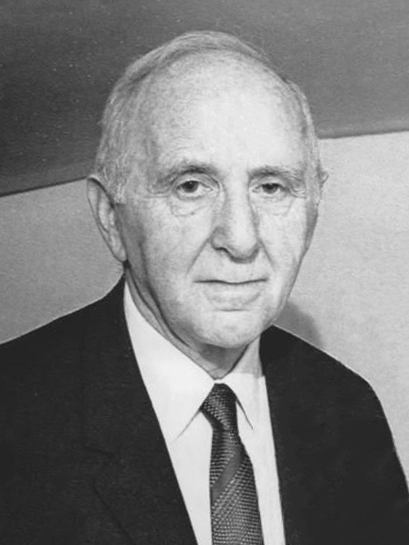

Figure 1: Simon Kuznets (1901–1985)

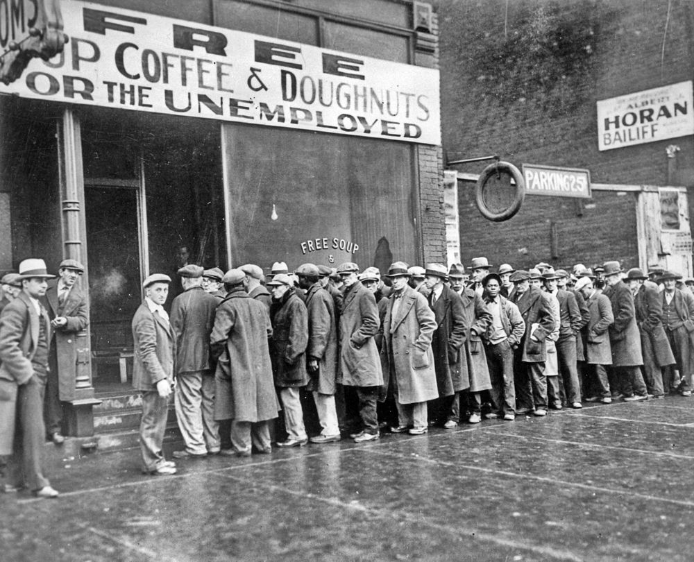

Great Depression

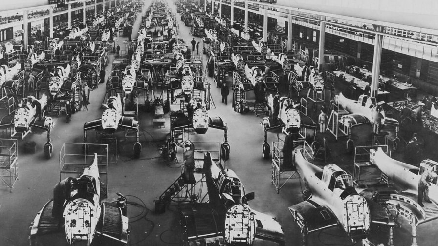

WW2 Economic Planning

## “Not a Measure of Welfare”

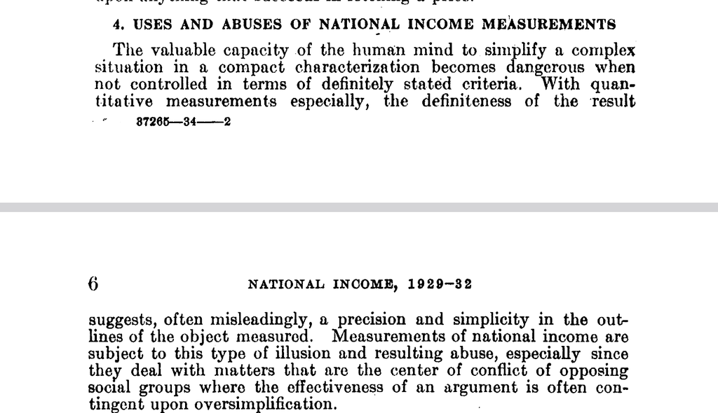

Kuznets (1934)

## How GDP Is Measured

## A Toy Economy

| Transaction | Amount |
| --- | --- |
| Farmer sells wheat to Miller | 300 |
| Miller sells flour to Bakery | 600 |
| Bakery sells bread to Households | 1000 |
| Farmer pays wages | 250 |
| Miller pays wages | 200 |
| Bakery pays wages | 350 |

Assume no imports, no taxes, no investment, no inventory change.

## A Toy Economy continued

1. **The baker’s mother bakes bread at home and gives it to neighbors.**
   - GDP: unchanged. The activity does not cross the market and is outside the production boundary.
2. **Half of the bread is wasted in households after they purchase it from the bakery**
   - GDP: *unchanged*. Production happened; sale happened. The fact that the bread was wasted is invisible to GDP.
3. **The bakery’s oven pollutes a river. A factory downstream installs a filter for €200.**
   - GDP: *increases by €200*.
4. **A storm destroys half the wheat crop. Insurance pays out and reconstruction begins.**
   - GDP: *increases*. Disasters increase GDP in the short run.
5. **The farmer’s land erodes 5% over the year.**
   - GDP: *unchanged*. Natural capital depreciation is not in standard national accounting.

## Can Growth Go Green?

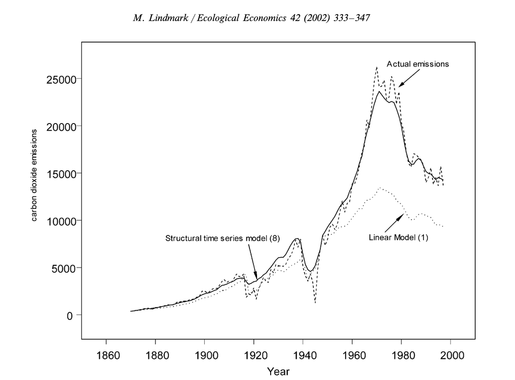

Figure 2: Empiricial Data on EKC in Sweden from Lindmark (2002, 340)

# Degrowth

## Not a Crash. Not a Recession.

### Recession

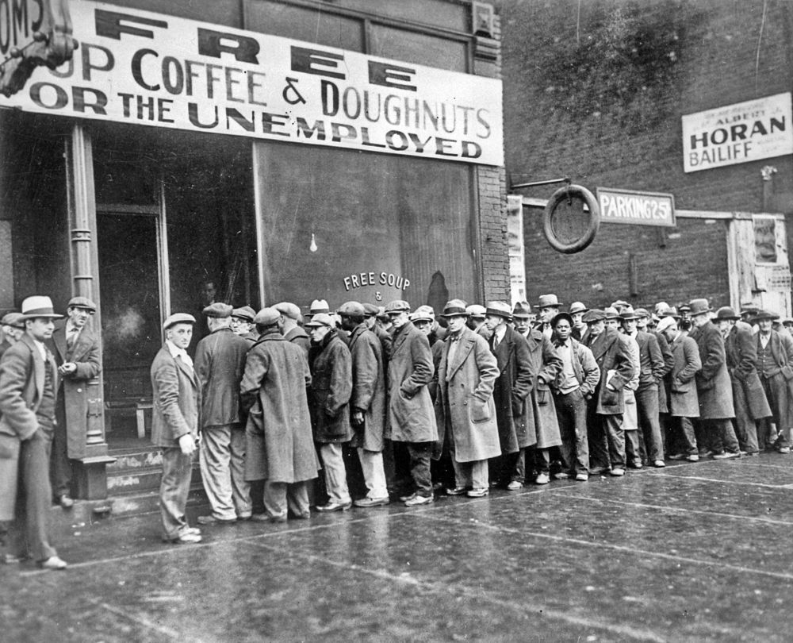

Figure 3: Great depression

Unintended.

GDP contracts; everything else degrades with it: employment, services, ecological stress per unit output often *rises*.

A failure of the growth economy.

### Degrowth

[figure not shown]

Figure 4: Planned degrowth

Intended.

A planned, equitable downscaling of throughput, with employment, services, and ecological integrity *protected* in the transition.

An alternative *to* the growth economy.

## A Missile Word

> Décroissance was launched by activists in 2001 as a challenge to growth.

Demaria et al. (2013) p. 191

## Slogan, Concept, Movement

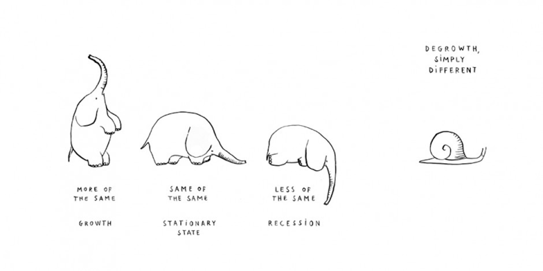

Figure 5: The elephant and the snail by Bàrbara Castro Urío

## Activist-Led Science

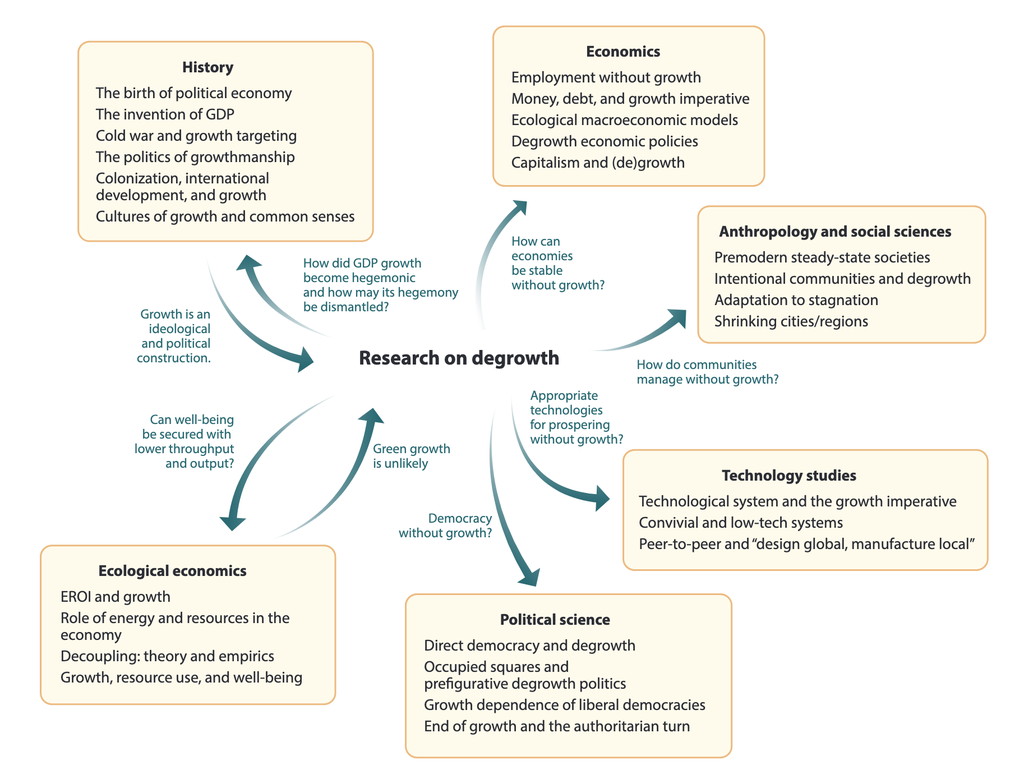

Figure 6: Degrowth research themes (Kallis et al. 2018, 293)

## A young field with a lot of teething issues (my opinion!)

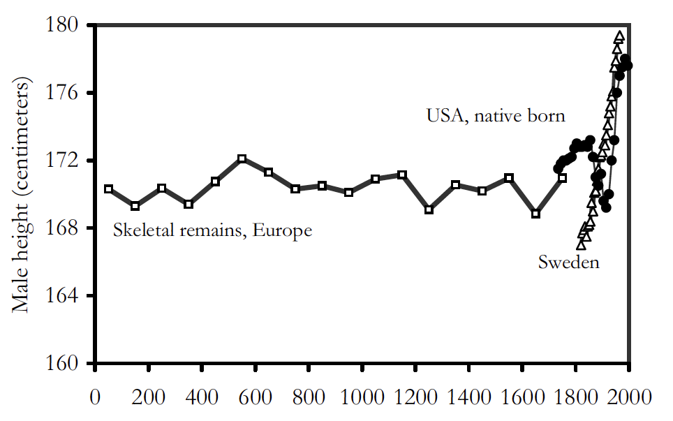

Figure 7: Historical Average Heights of Men (copied from Clark 2010)

# From Critique to Program

## Four Proposed Strategies

**Opposing**

**Practicing**

**Reforming**

**Communicating**

## Some Policy Proposals

- **Working time reduction.**
- **Universal basic income or universal basic services.**
- **Maximum and minimum income ratios.**
- **Job guarantee in care, repair, and ecological restoration sectors.**
- **Carbon and resource caps with shrinking allowances.**
- **Financial sector restructuring.**
- **Commons-based provisioning.**

## Open Questions

## Visioning Exercise: A Day in 2050

**Group exercise**

Form pairs. Pick **one** of these domains:

- Work — Food — Mobility — Housing — Care — Leisure

Imagine your everyday life in this domain in a degrowth society in **2050**.

What is different? What is the same? What is gained? What is lost?

## Checking In on Learning Objectives

**By the end of today’s lecture you should be able to:**

1. Explain how GDP is measured in practice and identify what its production boundary includes and excludes
2. Evaluate the empirical case for green growth, including the limits of the Environmental Kuznets Curve
3. Define degrowth as a slogan, an interpretative frame, and a field of research, and distinguish it from recession
4. Outline the main strategies and policy proposals associated with degrowth and articulate at least one open question

## References

Barlow, Nathan, Livia Regen, Noémie Cadiou, et al., eds. 2022. *Degrowth & Strategy: How to Bring about Social-Ecological Transformation*. Mayfly Books.

Clark, Gregory. 2010. *A Farewell to Alms: A Brief Economic History of the World*. The Princeton Economic History of the Western World. Princeton Univ. Press.

Demaria, Federico, François Schneider, Filka Sekulova, and Joan Martinez-Alier. 2013. “What Is Degrowth? From an Activist Slogan to a Social Movement.” *Environmental Values* 22 (2): 191–215. https://www.jstor.org/stable/23460978.

Kallis, Giorgos, Vasilis Kostakis, Steffen Lange, Barbara Muraca, Susan Paulson, and Matthias Schmelzer. 2018. “Research On Degrowth.” *Annual Review of Environment and Resources* 43 (Volume 43, 2018): 291–316. https://doi.org/10.1146/annurev-environ-102017-025941.

Kuznets, Simon. 1934. “National Income, 1929-1932.” In *National Income, 1929-1932*. NBER.

Lindmark, Magnus. 2002. “An EKC-pattern in Historical Perspective: Carbon Dioxide Emissions, Technology, Fuel Prices and Growth in Sweden 1870–1997.” *Ecological Economics* 42 (1): 333–47. https://doi.org/10.1016/S0921-8009(02)00108-8.